# Heat Mapping 1000 genomes data

1/28/2017

```r
library(TeachingPopGen)
library(hierfstat)
library(LDheatmap)
```

### Reading the data

A previously obtained VCF file, containing data for the hyal2 region, will be read - chromosome 3, base pairs 50,280,000-50,380,000

```r
flname <- "../Data/hyaDemo.vcf.gz"
#flname <-"./Data/mydata.vcf.gz"set
dat.vcf <- read.vcf(flname,quiet=TRUE)
dat.info <-VCFloci(flname,quiet = TRUE)
dat.vcf
```

```
## Allelic data frame: 2504 individuals
##                     2575 loci
```

```r
as.matrix(dat.vcf[1:5,1:5])
```

```
##         rs79233068 rs192601578 rs587763748 rs587638495 rs77677064
## HG00096 "G|G"      "C|C"       "C|C"       "C|C"       "G|G"
## HG00097 "G|G"      "C|C"       "C|C"       "C|C"       "G|G"
## HG00099 "G|G"      "C|C"       "C|C"       "C|C"       "G|G"
## HG00100 "G|G"      "C|C"       "C|C"       "C|C"       "G|G"
## HG00101 "G|G"      "C|C"       "C|C"       "C|C"       "G|G"
```

```r
str(dat.info)
```

```
## Classes 'VCFinfo' and 'data.frame':  2575 obs. of  9 variables:
##  $ CHROM : chr  "3" "3" "3" "3" ...
##  $ POS   : int  50280024 50280051 50280054 50280234 50280314 50280335 50280508 50280557 50280586 50280634 ...
##  $ ID    : chr  "rs79233068" "rs192601578" "rs587763748" "rs587638495" ...
##  $ REF   : chr  "G" "C" "C" "C" ...
##  $ ALT   : chr  "A" "T" "G" "T" ...
##  $ QUAL  : int  100 100 100 100 100 100 100 100 100 100 ...
##  $ FILTER: chr  "PASS" "PASS" "PASS" "PASS" ...
##  $ INFO  : chr  "AC=175;AF=0.0349441;AN=5008;NS=2504;DP=16418;EAS_AF=0;AMR_AF=0.0086;AFR_AF=0.1278;EUR_AF=0;SAS_AF=0;AA=G|||;VT=SNP" "AC=1;AF=0.000199681;AN=5008;NS=2504;DP=16711;EAS_AF=0.001;AMR_AF=0;AFR_AF=0;EUR_AF=0;SAS_AF=0;AA=C|||;VT=SNP" "AC=1;AF=0.000199681;AN=5008;NS=2504;DP=16949;EAS_AF=…
##  $ FORMAT: chr  "GT" "GT" "GT" "GT" ...
```

This includes data for all 26 populations. What we want to do is to look at two - CHB and TSI. The code below will do that:

```r
pops <- c("CHB","TSI")
dat.spl <- split.vcf(dat.vcf,pops)
dat.spl
```

```
## $CHB
## Allelic data frame: 103 individuals
##                     2575 loci
##
## $TSI
## Allelic data frame: 107 individuals
##                     2575 loci
```

### Cleaning up

There are two things we need to do, having split them up - remove invariant positions from each populations and then remove ones with MAF <0.05. Two TPG functions do that:

```r
dat.spl2 <- lapply(dat.spl,monogon) # remove monomorphic loci
dat.spl2 <- lapply(dat.spl2,setmaf) # remove any with MAF <0.05
dat.spl2
```

```
## $CHB
## Allelic data frame: 103 individuals
##                     117 loci
##
## $TSI
## Allelic data frame: 107 individuals
##                     71 loci
```

### Linkage Disequilibrium

Sometimes at this point, we need to sample from the loci to get a manageable number. However, in this case we don’t need to, so well skip the next chunk and set dat.spl2 to dat.smp

```r
dat.smp <-lapply(dat.spl2, function (x) x[,sample(1:ncol(x),100)])
dat.smp
```

Instead, we’ll proceed and extract the map positions of the selected SNPs from the information from the VCF file:

```r
dat.smp <-dat.spl2
map.n <-lapply(dat.smp, function(x) which(dat.info$ID %in% colnames(x)))
map.p <-lapply(map.n, function (x) dat.info$POS[x])
lapply(map.p,head)
```

```
## $CHB
## [1] 50280586 50281168 50281756 50283437 50284377 50285677
##
## $TSI
## [1] 50281168 50285677 50286953 50289635 50290902 50291617
```

mamp.p is the critical list - it contains two elements, each a vector containing the map position in base pairs of the snps for the two populations.

Now we apply the LDscan function to the data, which calculates r for each pairwise combination of SNPs.

```r
dat.ld <- lapply(dat.smp,LDscan,quiet=TRUE)
```

And then we use LDheatmap to make two heatmaps, one of each population.

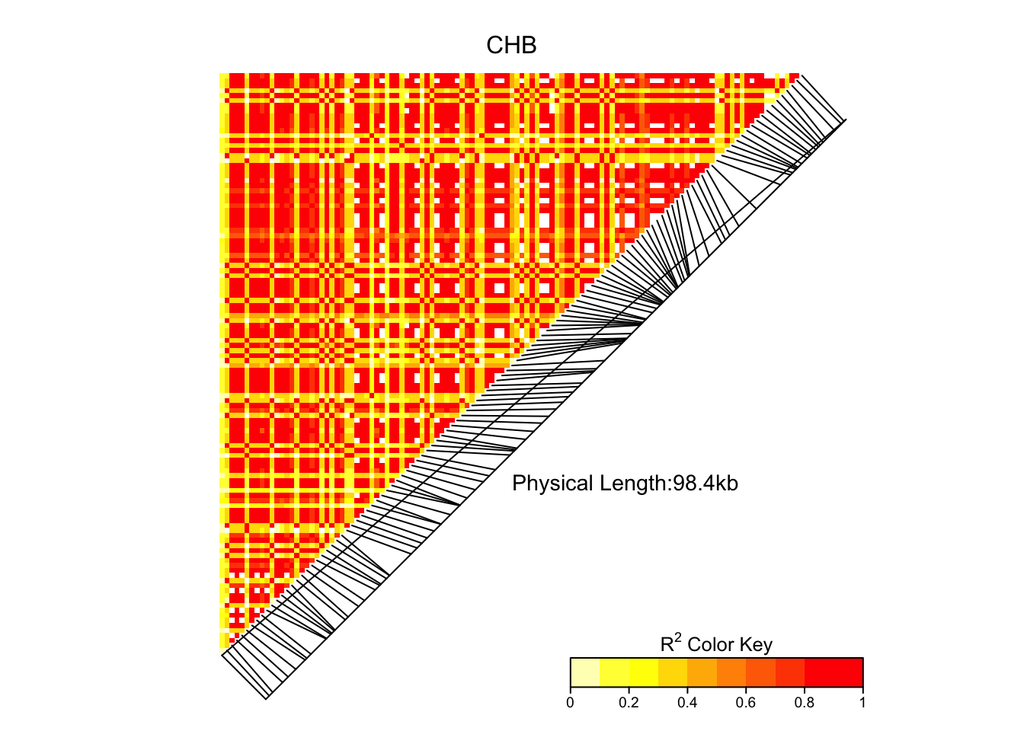

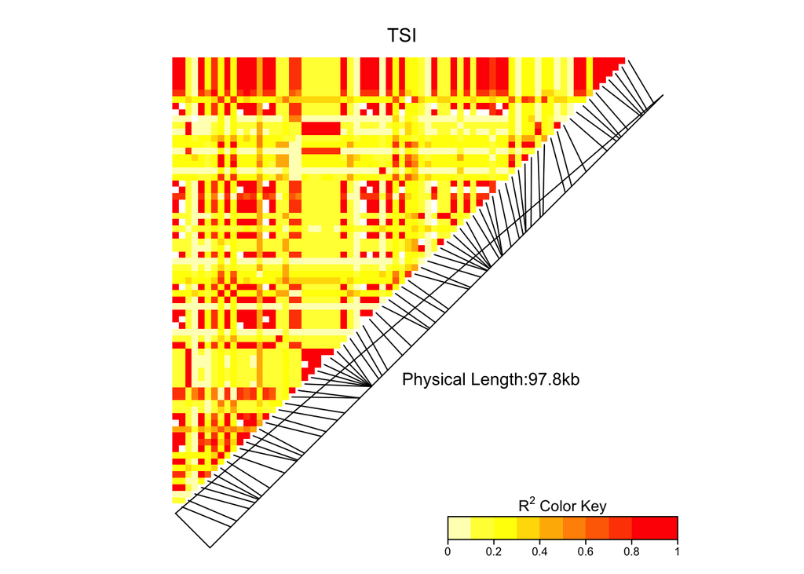

```r
ldmat <-lapply(dat.ld, as.matrix)
lx <-lapply(c(1:length(ldmat)), function(x) LDheatmap(ldmat[[x]],color=heat.colors(10),title=names(ldmat)[x],genetic.distances = map.p[[x]],text=FALSE,add.map=TRUE))
```

And we see that LD is much higher in the CHB sample than in the TSI one. Why is that? We will need to explore that further.